# Homework 2

Brian Baldwin

West Chester University STA553

# 1 Creating a Scatterplot of Penguin Bill Length vs Flipper Length

From size measurements for adult foraging penguins near Palmer Station, Antarctica, we wish to display a relationship between their bill and flipper lengths for a sample of the penguin species.

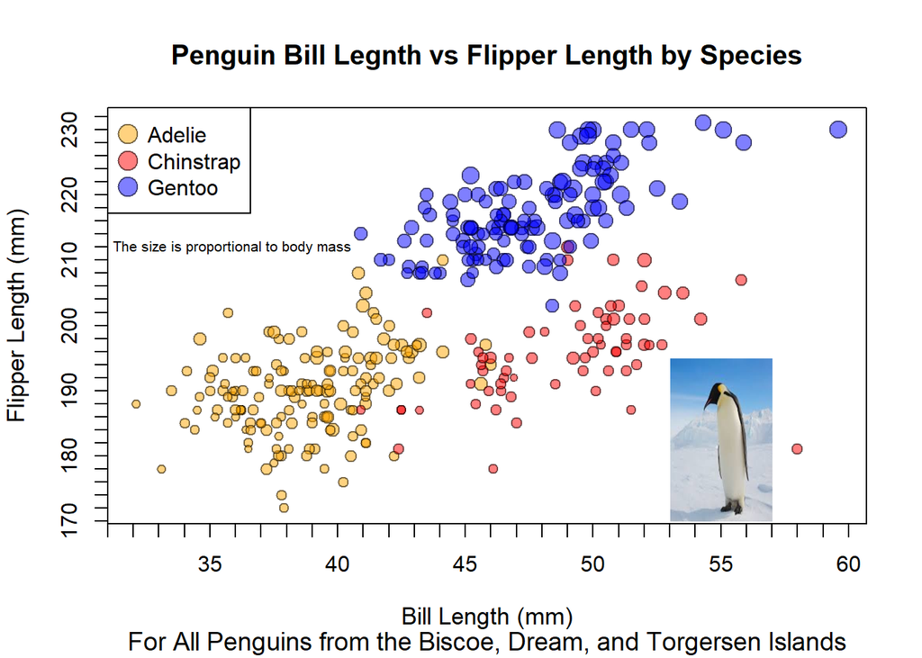

For each of the three species in the first graph, there is a significant moderate positive linear relationship between a penguin’s bill length and flipper length. Hence, as a penguin’s bill length increases, the length of its flipper tends to increase as well. However, for the Adelie species, there is a weaker relationship than for the other species (since the points are more spread out making it harder to see the positive relationship). From the scatterplot, we can also see that, on average, a Gentoo and Chinstrap penguin’s bill length is greater than an Adelie penguin’s, and a Gentoo penguin’s flipper length is greater than both Adelie and Chinstrap penguins, according to the sample.

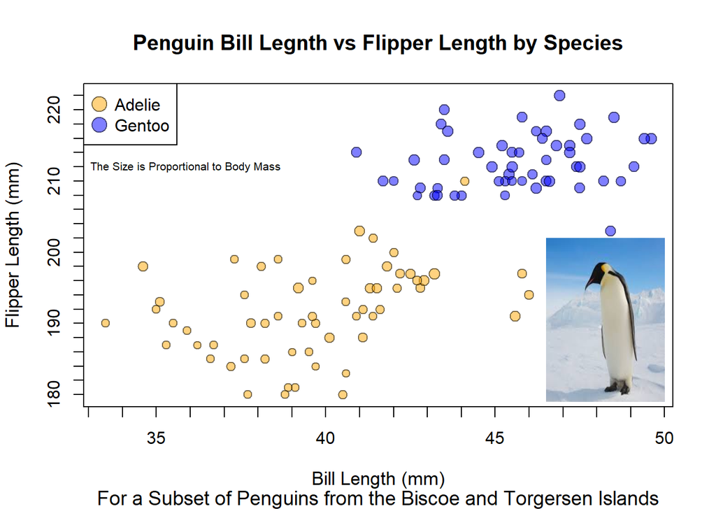

For the subset of penguins, there is a weak relationship between bill and flipper lengths within each species. For both Adelie and Gentoo species, as the bill length increases, the flipper length barley tends to increase, if it changes at all. This lack of a visible relationship could be due to the loss of information while subsetting the data based on species, island origin, body mass, etc. Although the fact that the flipper length for the Gentoo species being greater than the Adelie species, on average, is visible with the subsetted scatterplot, we lose a visible relationship between the variables bill length and flipper length within the species. However, there *IS* a visible positive linear relationship *overall* for bill and flipper lengths in the subsetted graph.